## 第1層 データマイニング手法からNeural Networkへ

この章では、読者が慣れ親しんだデータマイニング手法を、ニューラルネットワークに置き換えます。  
いきなりパーセプトロンがどうだよりはわかりやすかろうと。

とりあえずKaggleの手書き文字認識をします。  
http://www.kaggle.com/c/digit-recognizer

## 1.1 Logistic Regression

### 普通の方法

データを読み込んで、trainからvalidデータ切り出して、モデルを10個作ります。  
つまり、0かそうでないかを判別するモデル、1かそうでないかを判別するモデル、・・・

##### データ準備

まずはデータを読み込んで、使いやすい形に準備します。

```r
setwd("/Users/KeiHarada/Documents/digit")
traindata <- read.csv("ORG/train.csv")
testdata <- read.csv("ORG/test.csv")
train_label <- traindata$label[1:28000]
valid_label <- traindata$label[28001:42000]

# transform into array
train_array <- array(as.matrix(traindata[1:28000,-1]),dim=c(28000,28,28))
valid_array <- array(as.matrix(traindata[28001:42000,-1]),dim=c(14000,28,28))
```

Arrayに変換しているのは半分趣味です。  
image(行列)で画像っぽくPlotに出力されます。適宜チェックしてください。

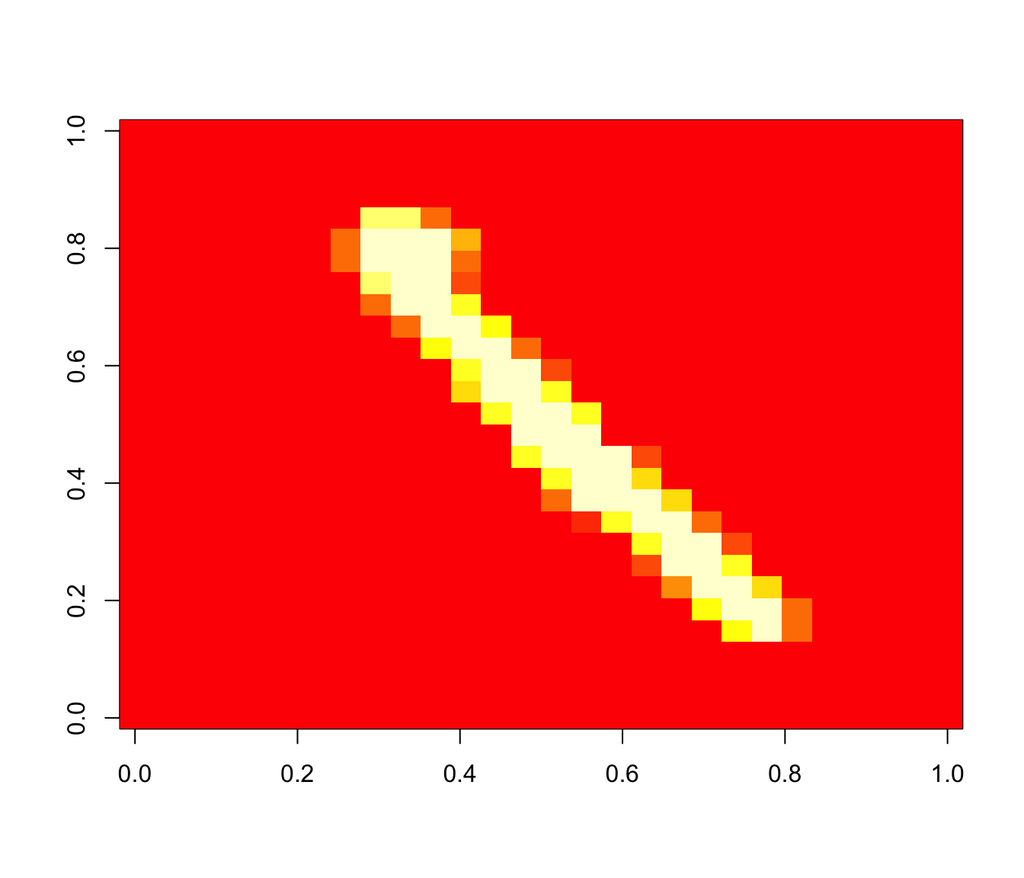

```r
# check
image(train_array[1,,])
```

##### データの圧縮

次に、28×28を説明変数にすると多すぎる気がするので、7×7に減らします。  
ついでにバイナリ(0/1)にしちゃいましょう。  
4×4の大きさのブロックに分割し(7×7個できます)、各ブロックの中に127より大きな値があれば1を、 そうでなければ0を出力とします。

```r
# resize(7*7)
# use max here
train_array_49 <- array(0,dim=c(28000,7,7))
for (i in seq(7)){
  for (j in seq(7)){
    for (row in seq(28000)){
      train_array_49[row,i,j] <- ifelse(max(train_array[row,((4*i-3):(4*i)),((4*j-3):(4*j))]) > 127,1,0)
    }
  }
}
```

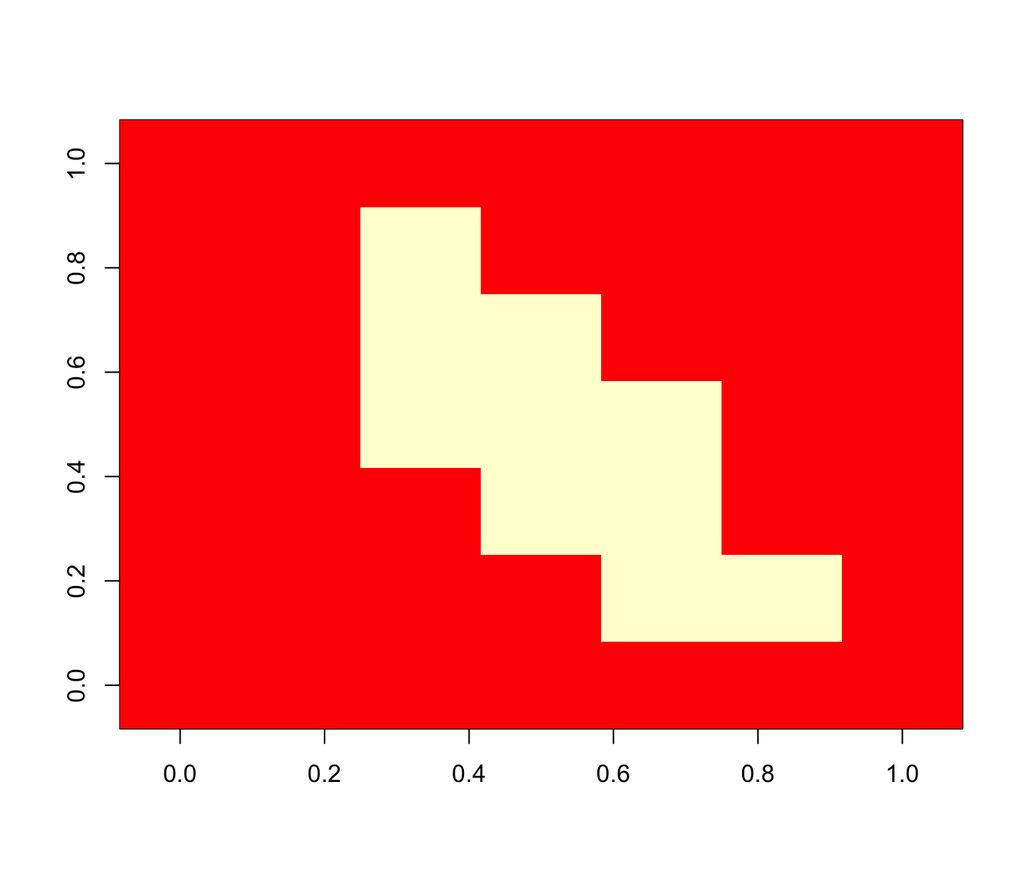

```r
# check
image(train_array_49[1,,])
```

```r
# image(train_array_49[2,,])
```

##### モデル構築

Rのデータフレームに変換して、glmで作ります。

```r
train49 <- as.data.frame(cbind(train_label,array(train_array_49,dim=c(28000,49))))
# check
# image(matrix(as.numeric(train49[1,-1]),ncol=7))
# image(matrix(as.numeric(train49[2,-1]),ncol=7))


# logistic regression
logit0 <- glm((train_label==0)~.,data=train49)
logit1 <- glm((train_label==1)~.,data=train49)
logit2 <- glm((train_label==2)~.,data=train49)
logit3 <- glm((train_label==3)~.,data=train49)
logit4 <- glm((train_label==4)~.,data=train49)
logit5 <- glm((train_label==5)~.,data=train49)
logit6 <- glm((train_label==6)~.,data=train49)
logit7 <- glm((train_label==7)~.,data=train49)
logit8 <- glm((train_label==8)~.,data=train49)
logit9 <- glm((train_label==9)~.,data=train49)
```

10個のモデルができました。最も大きな確率を返したものが、このモデル(群)としての出力とします。  
ちょっと精度を見てみましょう。  
ここでは誤分類率が低ければよしとします。(モデル構築時は対数尤度ですが)

```r
# fit
trainfit <- data.frame(
  p0 = 1 / (1 + exp(-1*predict(logit0,data=train49))),
  p1 = 1 / (1 + exp(-1*predict(logit1,data=train49))),
  p2 = 1 / (1 + exp(-1*predict(logit2,data=train49))),
  p3 = 1 / (1 + exp(-1*predict(logit3,data=train49))),
  p4 = 1 / (1 + exp(-1*predict(logit4,data=train49))),
  p5 = 1 / (1 + exp(-1*predict(logit5,data=train49))),
  p6 = 1 / (1 + exp(-1*predict(logit6,data=train49))),
  p7 = 1 / (1 + exp(-1*predict(logit7,data=train49))),
  p8 = 1 / (1 + exp(-1*predict(logit8,data=train49))),
  p9 = 1 / (1 + exp(-1*predict(logit9,data=train49)))
)


trainres <- max.col(as.matrix(trainfit)) - 1

# confusion matrix
table(trainres,train_label)
```

```
##         train_label
## trainres    0    1    2    3    4    5    6    7    8    9
##        0 2314    0  112   60   50  135   51   34   79   37
##        1    9 2970  153   88   60  134   28  210  227   52
##        2   19   20 1844  169   22   59   39   31   98   12
##        3   55    8  123 2072   10  422   11   47  160   79
##        4   21    7   88   15 1800   70   51  139   45  228
##        5   46   14    5   22  106 1298   26    6  184    4
##        6   84   33  246  101   53  122 2543    9   54    1
##        7    6   18   93  123  100   22    3 2152   48  163
##        8  150    9  133  187   58  195   18   49 1636  103
##        9   17   28   27   72  497   64    9  247  163 2086
```

```r
# Categorization Accuracy
mean(trainres == train_label)
```

```
## [1] 0.7398214
```

うん、まあまあの精度ですね。

### ニューラルネットワークっぽくする

今のモデルをニューラルネットワークっぽく作りましょう。

##### ネットワークの構成

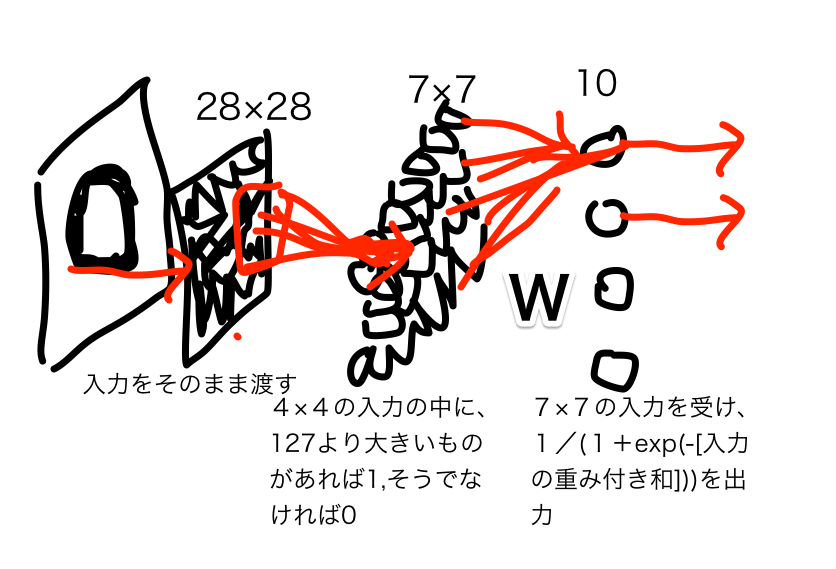

##### 数学的な整理

とりあえず、7×7のニューロンに番号をつけて、 その出力を$x_1, x_2, \dots, x_{49}$とします。  
その次にある10個のニューロンにも番号をつけて(1番目のニューロンが0かそうでないかを判別するとして)、その出力を$y_1, y_2, \dots, y_{10}$とします。このとき、  
$y_j = \sigma(\sum_{i=1}^{49} w_{ij}x_i+c_j)$ となります。ここで、  
* $w_{ij}$はj番目のニューロンがi番目のニューロンにつける重みです。  
* $c_j$はj番目のニューロンが常に1を出力するニューロンにつける重みです。  
* $\sigma$はシグモイド関数$\sigma(Z)=1 / (1 + \exp(-Z))$です。

$w_{ij}$と$c_j$の最適化をすると、さきほどのロジスティック回帰と同値になることがおわかりいただけるでしょうか。

##### 重みの最適化

```r
train49_mat <- cbind(train_label,array(train_array_49,dim=c(28000,49)))
# check
# image(matrix(train49_mat[1,-1],ncol=7))
# image(matrix(train49_mat[2,-1],ncol=7))

# answers
answer_mat <- matrix(0,nrow=28000,ncol=10)
for (i in seq(10)){
  answer_mat[train49_mat[,1]==(i-1),i] <- 1
}


# learn weights
W <- matrix(0.0,nrow=10,ncol=49)
intercept <- rep(0.0,length=10)

# learn rate
eta <- 0.001

for (i in seq(28000)){
  # feed forward
  output <- 1 / (1 + exp(-1*(W %*% train49_mat[i,-1] + intercept)))

  # back propagation
  W <- W + eta * (answer_mat[i,] - output) %*% t(train49_mat[i,-1])
  intercept <- intercept + eta * (answer_mat[i,] - output)

}

output_mat <- 1 / (1 + exp(-1*(train49_mat[,-1] %*% t(W) + matrix(1,nrow=28000,ncol=1) %*% matrix(intercept,ncol=10))))

trainres <- max.col(as.matrix(output_mat)) - 1
```

confusion matrix

```r
table(trainres,train_label)
```

```
##         train_label
## trainres    0    1    2    3    4    5    6    7    8    9
##        0 2366    3  202  100   67  160   98   39  132   53
##        1    9 2828   52   56   22   97   67  107  164   40
##        2   20   56 2062  272   31   80   69   33  134   17
##        3   39   12   58 1894    8  527    2   19  133   58
##        4   21    1   81    9 1678   97   63  107   19  218
##        5   15   13    4   46   17  917   40    1   97    4
##        6   99   35  173  106   71  162 2397   11   90    3
##        7    1   40   52  101  148   38    2 2145   62  307
##        8  141   65  120  241  157  354   35  181 1694  226
##        9   10   54   20   84  557   89    6  281  169 1839
```

Categorization Accuracy

```r
mean(trainres == train_label)
```

```
## [1] 0.7078571
```